# Inference for numerical data

```r
library(tidyverse)
library(openintro)
library(infer)
```

### Exercise 1

#### What are the cases in this data set? How many cases are there in our sample?

```r
data('yrbss', package='openintro')
```

```r
?yrbss
```

```r
glimpse(yrbss)
```

```
## Rows: 13,583
## Columns: 13
## $ age                      <int> 14, 14, 15, 15, 15, 15, 15, 14, 15, 15, 15, 1…
## $ gender                   <chr> "female", "female", "female", "female", "fema…
## $ grade                    <chr> "9", "9", "9", "9", "9", "9", "9", "9", "9", …
## $ hispanic                 <chr> "not", "not", "hispanic", "not", "not", "not"…
## $ race                     <chr> "Black or African American", "Black or Africa…
## $ height                   <dbl> NA, NA, 1.73, 1.60, 1.50, 1.57, 1.65, 1.88, 1…
## $ weight                   <dbl> NA, NA, 84.37, 55.79, 46.72, 67.13, 131.54, 7…
## $ helmet_12m               <chr> "never", "never", "never", "never", "did not …
## $ text_while_driving_30d   <chr> "0", NA, "30", "0", "did not drive", "did not…
## $ physically_active_7d     <int> 4, 2, 7, 0, 2, 1, 4, 4, 5, 0, 0, 0, 4, 7, 7, …
## $ hours_tv_per_school_day  <chr> "5+", "5+", "5+", "2", "3", "5+", "5+", "5+",…
## $ strength_training_7d     <int> 0, 0, 0, 0, 1, 0, 2, 0, 3, 0, 3, 0, 0, 7, 7, …
## $ school_night_hours_sleep <chr> "8", "6", "<5", "6", "9", "8", "9", "6", "<5"…
```

There are 13,583 observations in this dataset and each row represents a student between 9th and 12th grade in public or private school in the US.

### Exercise 2

#### How many observations are we missing weights from?

```r
summary(yrbss$weight)
```

```
##    Min. 1st Qu.  Median    Mean 3rd Qu.    Max.    NA's
##   29.94   56.25   64.41   67.91   76.20  180.99    1004
```

We have 1,004 NAs so that’s how many we’re missing.

### Exercise 3

#### Make a side-by-side boxplot of `physical_3plus` and `weight`. Is there a relationship between these two variables? What did you expect and why?

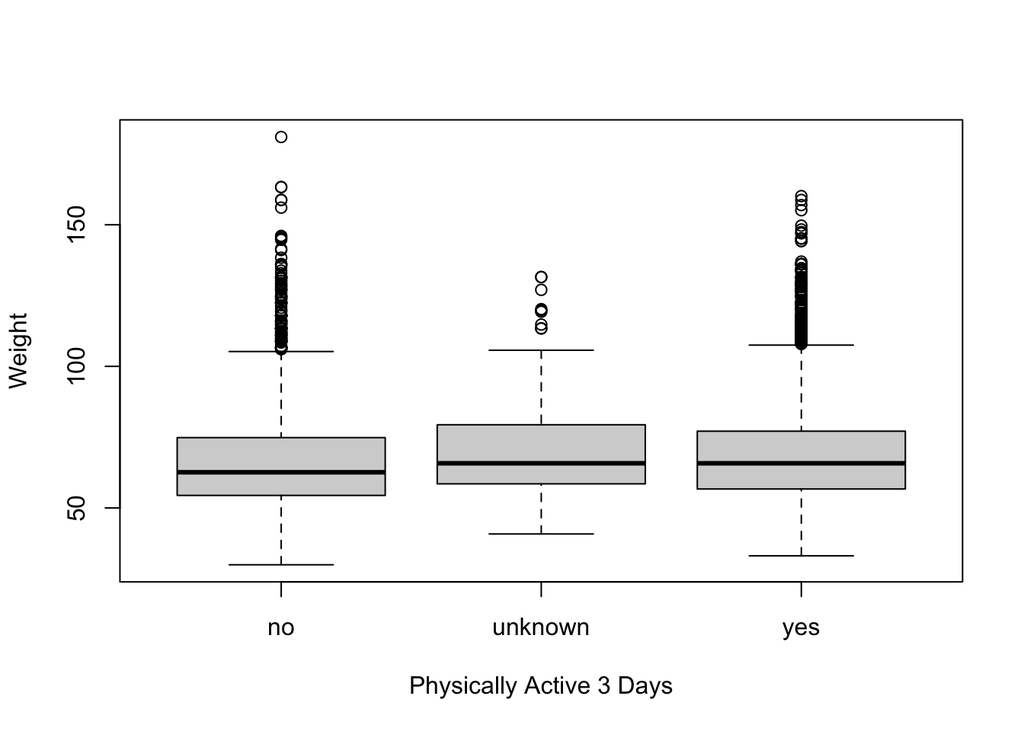

```r
yrbss <- yrbss %>%
  mutate(physical_3plus = replace_na(ifelse(yrbss$physically_active_7d > 2, "yes", "no"), "unknown"))

boxplot(yrbss$weight ~ yrbss$physical_3plus, data=yrbss, ylab="Weight", xlab="Physically Active 3 Days")
```

### Exercise 4

#### Are all conditions necessary for inference satisfied? Comment on each. You can compute the group sizes with the `summarize` command above by defining a new variable with the definition `n()`.

The conditions necessary for inference are:

- Random: we can assume that the survey respondents were randomly selected.
- Normal: given the sample size is 13k+, that is more than 30 and so we can assume it’s normal.
- Independent: there has not been resampling and our sample size is not more than 10% of the population

### Exercise 6

#### How many of these `null` permutations have a difference of at least `obs_stat`?

```r
obs_diff <- yrbss %>% filter(physical_3plus != "unknown") |>
  specify(weight ~ physical_3plus) %>%
  calculate(stat = "diff in means", order = c("yes", "no"))
obs_diff
```

```
## Response: weight (numeric)
## Explanatory: physical_3plus (factor)
## # A tibble: 1 × 1
##    stat
##   <dbl>
## 1  1.77
```

```r
null_dist <- yrbss %>% filter(physical_3plus != "unknown") |>
  specify(weight ~ physical_3plus) %>%
  hypothesize(null = "independence") %>%
  generate(reps = 1000, type = "permute") %>%
  calculate(stat = "diff in means", order = c("yes", "no"))
```

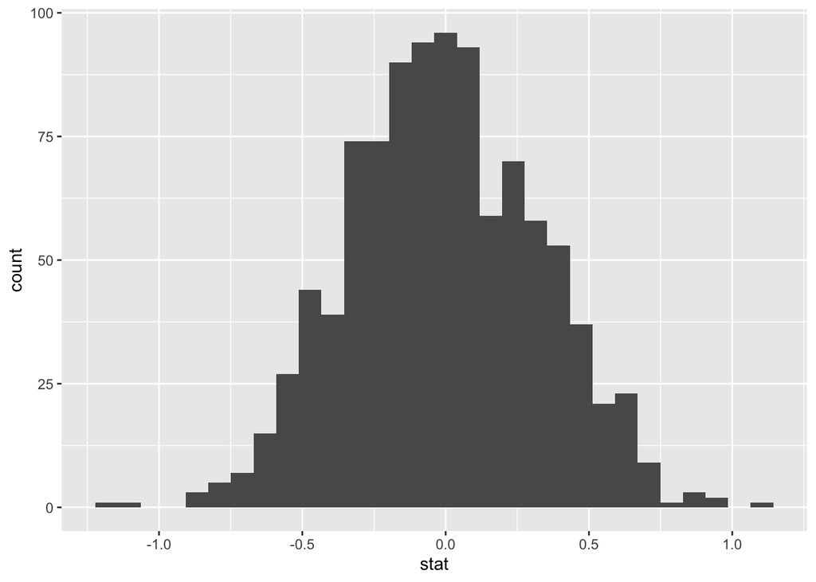

```r
ggplot(data = null_dist, aes(x = stat)) +
  geom_histogram()
```

So `obs_diff`’s stat is 1.77 – none of these permutations get up to that, it looks like the max in the distribution is a little over 1.0.

### Exercise 7

#### Construct and record a confidence interval for the difference between the weights of those who exercise at least three times a week and those who don’t, and interpret this interval in context of the data.

```r
ex7 <- yrbss %>%
  group_by(physical_3plus) %>%
  summarise(mean_weight = mean(weight, na.rm = TRUE),
            sd_weight = sd(weight, na.rm = TRUE),
            count = n())
z <- 1.96

not_active <- ex7 |> filter(physical_3plus == "no")

not_active_mean <- not_active |> select(mean_weight)
not_active_sd <- not_active |> select(sd_weight)
not_active_count <- not_active |> select(count)

active <- ex7 |> filter(physical_3plus == "yes")

active_mean <- active |> select(mean_weight)
active_sd <- active |> select(sd_weight)
active_count <- active |> select(count)

# confidence interval for not active
upper_not_active <- not_active_mean$mean_weight + z * (not_active_sd$sd_weight / sqrt(not_active_count$count))
lower_not_active <- not_active_mean$mean_weight - z * (not_active_sd$sd_weight / sqrt(not_active_count$count))
sprintf("The 95 percent confidence interval for not physically active students' weight is %f to %f", lower_not_active, upper_not_active)
```

```
## [1] "The 95 percent confidence interval for not physically active students' weight is 66.152952 to 67.194821"
```

```r
# confidence interval for active
upper_active <- active_mean$mean_weight + z * (active_sd$sd_weight / sqrt(active_count$count))
lower_active <- active_mean$mean_weight - z * (active_sd$sd_weight / sqrt(active_count$count))
sprintf("The 95 percent confidence interval for physically active students' weight is %f to %f", lower_active, upper_active)
```

```
## [1] "The 95 percent confidence interval for physically active students' weight is 68.106233 to 68.790708"
```

Seeing as the two confidence intervals do not overlap, we are 95% confident that there is a difference in weight between these two groups; we reject the null hypothesis.

### Exercise 8

#### Calculate a 95% confidence interval for the average height in meters (`height`) and interpret it in context.

```r
ex8 <- yrbss %>%
  summarise(mean_height = mean(height, na.rm = TRUE),
            sd_height = sd(height, na.rm = TRUE),
            count = n())

z <- 1.96

height_mean <- ex8 |> select(mean_height)
height_sd <- ex8 |> select(sd_height)
height_count <- ex8 |> select(count)

# confidence interval for height
upper_height <- height_mean$mean_height + z * (height_sd$sd_height / sqrt(height_count$count))
lower_height <- height_mean$mean_height - z * (height_sd$sd_height / sqrt(height_count$count))
sprintf("The 95 percent confidence interval for the height of students is %f to %f", lower_height, upper_height)
```

```
## [1] "The 95 percent confidence interval for the height of students is 1.689480 to 1.693002"
```

We are 95% confident that the average height of a student is between 1.689 and 1.693 meters.

### Exercise 9

#### Calculate a new confidence interval for the same parameter at the 90% confidence level. Comment on the width of this interval versus the one obtained in the previous exercise.

```r
z <- 1.65

# confidence interval for height
upper_height <- height_mean$mean_height + z * (height_sd$sd_height / sqrt(height_count$count))
lower_height <- height_mean$mean_height - z * (height_sd$sd_height / sqrt(height_count$count))
sprintf("The 90 percent confidence interval for the height of students is %f to %f", lower_height, upper_height)
```

```
## [1] "The 90 percent confidence interval for the height of students is 1.689759 to 1.692723"
```

We are 90% confident that the average height of a student is between 1.690 and 1.693 meters. Since all numbers except the critical value are the same, the confidence interval is smaller in width as the confidence level goes down.

### Exercise 10

#### Conduct a hypothesis test evaluating whether the average height is different for those who exercise at least three times a week and those who don’t.

H0: The average height between students who exercise 3+ times a week and students who don’t are the same. H1: The average height between students who exercise 3+ times a week and students who don’t are not the same.

```r
ex10 <- yrbss %>%
  group_by(physical_3plus) %>%
  summarise(mean_height = mean(height, na.rm = TRUE),
            sd_height = sd(height, na.rm = TRUE),
            count = n())
z <- 1.96

not_active <- ex10 |> filter(physical_3plus == "no")

not_active_mean <- not_active |> select(mean_height)
not_active_sd <- not_active |> select(sd_height)
not_active_count <- not_active |> select(count)

active <- ex10 |> filter(physical_3plus == "yes")

active_mean <- active |> select(mean_height)
active_sd <- active |> select(sd_height)
active_count <- active |> select(count)

# confidence interval for not active
upper_not_active <- not_active_mean$mean_height + z * (not_active_sd$sd_height / sqrt(not_active_count$count))
lower_not_active <- not_active_mean$mean_height - z * (not_active_sd$sd_height / sqrt(not_active_count$count))
sprintf("The 95 percent confidence interval for not physically active students' height is %f to %f", lower_not_active, upper_not_active)
```

```
## [1] "The 95 percent confidence interval for not physically active students' height is 1.662549 to 1.668625"
```

```r
# confidence interval for active
upper_active <- active_mean$mean_height + z * (active_sd$sd_height / sqrt(active_count$count))
lower_active <- active_mean$mean_height - z * (active_sd$sd_height / sqrt(active_count$count))
sprintf("The 95 percent confidence interval for physically active students' height is %f to %f", lower_active, upper_active)
```

```
## [1] "The 95 percent confidence interval for physically active students' height is 1.701067 to 1.705358"
```

As these do not overlap, we reject the null hypothesis and are 95% confident that students who exercise 3+ times a week have a taller height than students who don’t.

### Exercise 11

#### Now, a non-inference task: Determine the number of different options there are in the dataset for the `hours_tv_per_school_day` there are.

```r
ex11 <- yrbss %>%
  group_by(hours_tv_per_school_day) %>%
  summarise(count = n())
ex11
```

```
## # A tibble: 8 × 2
##   hours_tv_per_school_day count
##   <chr>                   <int>
## 1 <1                       2168
## 2 1                        1750
## 3 2                        2705
## 4 3                        2139
## 5 4                        1048
## 6 5+                       1595
## 7 do not watch             1840
## 8 <NA>                      338
```

There are 8 options here: < 1, 1-4, 5+, do not watch, and then people who didn’t respond.

### Exercise 12

#### Come up with a research question evaluating the relationship between height or weight and sleep. Formulate the question in a way that it can be answered using a hypothesis test and/or a confidence interval. Report the statistical results, and also provide an explanation in plain language. Be sure to check all assumptions, state your $\alpha$ level, and conclude in context.

Are students who get at least 8 hours of sleep taller?

We are assuming that all conditions for inference are satisfied:

- Random: we can assume that the survey respondents were randomly selected.
- Normal: given the sample size is 13k+, that is more than 30 and so we can assume it’s normal.
- Independent: there has not been resampling and our sample size is not more than 10% of the population

H0: There is no difference in average height for students depending on whether they get 8+ hours of sleep or not. H1: There is a difference in average height for students depending on whether they get 8+ hours of sleep or not.

```r
yrbss <- yrbss %>%
  mutate(sleep_8plus = replace_na(ifelse(yrbss$school_night_hours_sleep >= 8, "yes", ifelse(yrbss$school_night_hours_sleep == "10+", "yes", "no")), "unknown"))

ex12 <- yrbss %>%
  group_by(sleep_8plus) %>%
  summarise(mean_height = mean(height, na.rm = TRUE),
            sd_height = sd(height, na.rm = TRUE),
            count = n())
z <- 1.96

no_sleep <- ex12 |> filter(sleep_8plus == "no")

no_sleep_mean <- no_sleep |> select(mean_height)
no_sleep_sd <- no_sleep |> select(sd_height)
no_sleep_count <- no_sleep |> select(count)

sleep <- ex12 |> filter(sleep_8plus == "yes")

sleep_mean <- sleep |> select(mean_height)
sleep_sd <- sleep |> select(sd_height)
sleep_count <- sleep |> select(count)

# confidence interval for not active
upper_no_sleep <- no_sleep_mean$mean_height + z * (no_sleep_sd$sd_height / sqrt(no_sleep_count$count))
lower_no_sleep <- no_sleep_mean$mean_height - z * (no_sleep_sd$sd_height / sqrt(no_sleep_count$count))
sprintf("The 95 percent confidence interval for students who don't sleep 8+ hours' height is %f to %f", lower_no_sleep, upper_no_sleep)
```

```
## [1] "The 95 percent confidence interval for students who don't sleep 8+ hours' height is 1.687895 to 1.692304"
```

```r
# confidence interval for active
upper_sleep <- sleep_mean$mean_height + z * (sleep_sd$sd_height / sqrt(sleep_count$count))
lower_sleep <- sleep_mean$mean_height - z * (sleep_sd$sd_height / sqrt(sleep_count$count))
sprintf("The 95 percent confidence interval for students who sleep 8+ hours' height is %f to %f", lower_sleep, upper_sleep)
```

```
## [1] "The 95 percent confidence interval for students who sleep 8+ hours' height is 1.688781 to 1.695537"
```

Given these confidence intervals do overlap, we cannot reject the null hypothesis at 95% confidence.